# Command Line Interface

7.0.0  
Command Line Interface

- [ Index ]
- Overview
  - Synopsis
  - Comparison with the X-CUBE-AI UI plug-in features
  - Command work-flow
  - Enable AutoML pipeline for resource-constrained environment
  - Error handling
- Common arguments
- Analyze command
  - Description
  - Specific arguments
  - Examples
  - DL framework detection
  - Out-of-the-box information
  - IR graph description
  - Complexity report per layer
  - C-graph description
- Validate command
  - Description
  - Specific arguments
  - Examples
  - Serial COM port configuration
  - Extended complexity report per layer
  - Execution time per layer
- Generate command
  - Description
  - Specific arguments
  - Examples
  - Particular network data c-file
  - Update an ioc-based project
  - Update a proprietary source tree
- Supported-ops command
  - Description
  - Specific arguments
  - Examples
- References

# Command Line Interface

X-CUBE-AI Expansion Package

r4.0

AI PLATFORM r7.0.0 (Embedded Inference Client API 1.1.0)

Command Line Interface r1.5.1

# Overview

The stm32ai application is a console utility which provides a complete and unified *Command Line Interface* (CLI) to generate from a pre-trained DL/ML model, an optimized library for STM32 device family. It consists on three main commands: **analyze**, **validate** and **generate**. Each command can be used independently of the other with the same set of common options (model files, compression factor, output directory…) and specific options. The **quantize** command is a specific command to apply a post-training quantization process (refer to [QUANT]). The **supported-ops** allows to list the supported operators and associated constraints for a given deep learning framework.

## Synopsis

```powershell
Neural Network Tools for STM32AI v1.5.1 (STM.ai v7.0.0)
usage: stm32ai.py [-h] [--version] [--tools-version] [--model FILE]
                  [--verbosity [{0,1,2}]] [--type [keras|onnx|tflite]]
                  [--name STR] [--compression [1|4|8]] [--quantize [FILE]]
                  [--custom FILE] [--allocate-inputs] [--allocate-outputs]
                  [--workspace DIR] [--output DIR] [--split-weights]
                  [--no-onnx-optimizer] [--no-onnx-io-transpose]
                  [--prefetch-compressed-weights] [--binary] [--dll] [--ihex]
                  [--address ADDR] [--copy-weights-at ADDR] [--relocatable]
                  [--lib DIR] [--series STR] [--no-c-files] [--batch-size INT]
                  [--mode MODE] [--desc DESC] [--valinput FILE [FILE ...]]
                  [--valoutput FILE [FILE ...]] [--range RANGE RANGE] [--full]
                  [--save-csv] [--classifier] [--no-check] [--no-exec-model]
                  [--seed SEED] [--with-report]
                  analyze|generate|validate|quantize|supported-ops
```

Short description can be displayed with the following command:

```powershell
$ stm32ai --help
```

**Note** — In this article, *Netron* application (https://github.com/lutzroeder/netron) is used to visualize the original neural network model.

## Comparison with the X-CUBE-AI UI plug-in features

The stm32ai application is used as back-end by the X-CUBE-AI UI plug-in (refer to [[UM]](https://www.st.com/resource/en/user_manual/dm00570145.pdf)).

[figure not shown]

Figure 1: CLI as back-end

In comparison with the X-CUBE-AI UI plug-in, the following high-level features are not supported:

- extra C-code wrapper to manage multiple models. CLI manages only one model at the time.
- creation of a whole IDE project including the optimized inference runtime library, AI headers files and the C-files related to the HW settings. CLI can be only used to generate the specialized NN C-files. However, it allows to update an initial IDE project, STM32CubeMX-based or proprietary source tree (see “Update an ioc-based project” section).
- the check to know if a model will fit, in term of memory layout in a selected STM32 memory device. CLI reports (see analyze command) only the main system level dimensioning metrics: ROM, RAM, MACC.. (refer to [METRIC] for details)
- for the “*Validation process on target*”, as a full STM32 project is expected, it must be generated previously through the UI. Note that this project can be updated later (see “Update an ioc-based project” section). “*Validation process on desktop*” is fully supported through the CLI without restriction.
- graphic visualization of the generated c-graph (including the usage of the RAM). CLI provides only a textual representation (table form) of the c-graph including a description of the tensors/operators (see analyze command).

## Command work-flow

For each command, the same preliminary steps are applied. A report (txt file) is systematically created and fully or partially displayed. Additional JSON files (dictionary based) are generated in the workspace directory to be parsed by the X-CUBE-AI plug-in to retrieve the results. Note that they can be also used by a non-regression environment. The format of these files is out of the scope of this document.

```
<workspace-directory-path>\<name>_report.json, <name>_c_graph.json
<output-directory-path>\<name>_<cmd_name>_report.txt
```

- `'analyze'` flow
  - import the model
  - map, render and optimize internally the model
  - log and display a report
- `'validate'` flow
  - import the model
  - map, render and optimize internally the model
  - execute the generated C-model (on desktop or from the STM32 target)
  - execute the original model using original deep learning runtime framework for x86
  - evaluate the metrics
  - log and display a report
- `'generate'` flow
  - import the model
  - map, render and optimize internally the model
  - export the specialized C-files
  - log and display a report

## Enable AutoML pipeline for resource-constrained environment

CLI can be integrated in an automatic or manual pipeline, to design a deployable and effective neural network architectures for resource-constrained environment (i.e. with low memory/computational resources and/or critical power consumption budgets). The main loop can be extended with a post-analyzing/validating steps of the pre-trained model candidates to check and to take into account the end-user target constraints thanks to the respective analyze and validate commands.

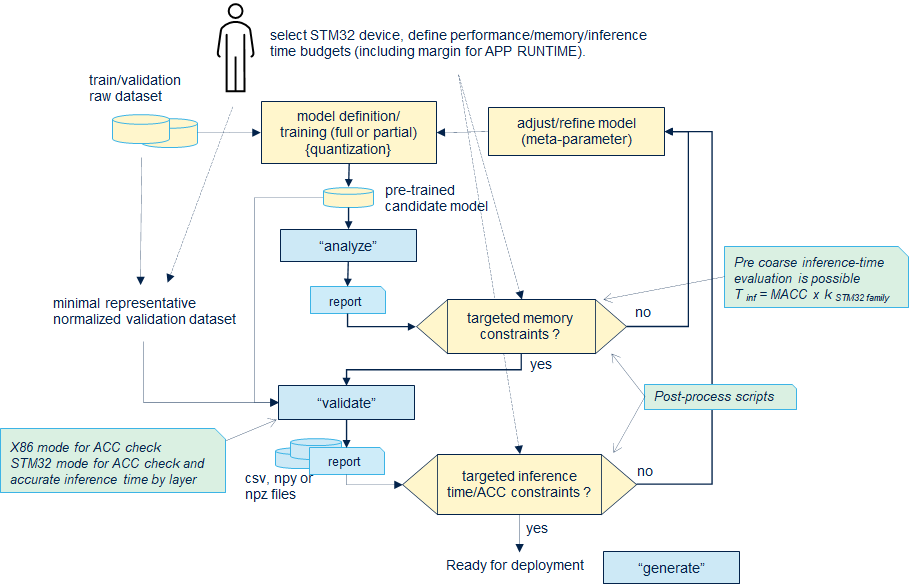

Figure 2: Possible AutoML flow with post deployment check

- checking of the budgeted memory (ROM/RAM) can be done in the inner (topology selection/definition) before the time-consuming training process (or re-training process) to pre-constraint the choices of the neural network architecture according the memory budgets.
- note that the “analyze” and “X86 validate” step can be merged, “analyze” information are also available in the “validate” reports.

## Error handling

During the execution of a given command, after the parsing of the arguments if an error is raised, the stm32ai application returns `-1` (else `0` is returned).

An error message is prefixed by a category and a short description.

| category | description |
| --- | --- |
| CLI ERROR | specific STM.ai/CLI error |
| LOAD ERROR | error during the load/import of the model or the connection with the STM32 board - OSError, IOError |
| NOT IMPLEMENTED | expected feature is not implemented - NotImplementedError |
| INTERRUPT | indicates that the execution of the command has been interrupted by the user (`CTRL-C` or kill system signal) - KeyboardInterrupt, SystemExit |
| TOOLS ERROR, INTERNAL ERROR | internal error - ImportError, RuntimeError, ValueError |

**Warning** — There is a specific attention to have explicit and relevant short description of the error messages. Unfortunately, this is not always case, additional TIPS and TRICKS can be found in the FAQ article or don’t hesitate to use the [ST Community channel/forum](https://community.st.com/s/topic/0TO0X0000003iUqWAI/stm32-machine-learning-ai) or local support.

**Example of specific error**

```powershell
$ stm32ai validate model.tflite -t keras
Neural Network Tools for STM32AI v1.5.1 (STM.ai v7.0.0)

E102(CliArgumentError): Wrong model files for 'keras'
```

# Common arguments

Following table describes the common arguments for the analyze, validate and generate commands. The specific arguments are described in the respective command section.

[output not shown]

# Analyze command

## Description

The `'analyze'` command is the primary command to import, to parse, to check and to render an uploaded pre-trained model. Detailed report provides the main system metrics to know if the generated code can be deployed on a STM32 device. It includes also rendering information by layer or/and operator (see “C-graph description” section). After completion, the user can be fully *confident* on the imported model in term of supported layer/operators.

## Specific arguments

Only the “Common” arguments are considered.

## Examples

- Analyze a model (simple model file)

  ```powershell
  $ stm32ai analyze -m <model_file_path>
  ```

- Analyze a 32b float model with compression request

  ```powershell
  $ stm32ai analyze -m <model_file_path> -c 8
  ```

- Analyze a model with input tensors placed in activations buffer

  ```powershell
  $ stm32ai analyze -m <model_file_path> --allocate-inputs
  ```

- Analyze a Keras post-quantized model (refer to [QUANT])

  ```powershell
  $ stm32ai analyze -m <modified_model_file>.h5 -q <quant_file_desc>.json
  ```

## DL framework detection

Extension of the model files are used to identify the DL framework which should be used to import the model. If the auto-detection is ambiguous, the `'--type/-t'` option should be used to define the correct framework.

| DL framework | type (–type/-t) | file extension |
| --- | --- | --- |
| Keras | `keras` | `.h5` or `.hdf5` and `.json` or `.yml` or `yaml` |
| TensorFlow lite | `tflite` | `.tflite` |
| ONNX | `onnx` | `.onnx` |

## Out-of-the-box information

The first part of the log shows the used arguments and the main system dimensioning C-model properties.

```powershell
$ stm32ai analyze -m ds_cnn.h5
Neural Network Tools for STM32AI v1.5.1 (STM.ai v7.0.0)

 Exec/report summary (analyze)
 -----------------------------------------------------------------------------
 model file         : <model-directory-path>\ds_cnn.h5
 type               : keras
 c_name             : network
 workspace dir      : <workspace-directory-path>
 output dir         : <output-directory-path>

 model_name         : ds_cnn
 model_hash         : cea66c686b2a1529d82848dc1fd0d873
 input              : input_0 [490 items, 1.91 KiB, ai_float, FLOAT32, (49, 10, 1)]
 inputs (total)     : 1.91 KiB
 output             : dense_1_nl [12 items, 48 B, ai_float, FLOAT32, (1, 1, 12)]
 outputs (total)    : 48 B
 params #           : 40,140 items (156.80 KiB)
 macc               : 4,833,536
 weights (ro)       : 159,536 B (155.80 KiB) / -1,024(-0.6%) vs original model
 activations (rw)   : 57,600 B (56.25 KiB)
 ram (total)        : 59,608 B (58.21 KiB) = 57,600 + 1,960 + 48
...
```

Initial sub-section recalls the CLI arguments. Note that the full raw command line is saved at the beginning of the generated report file: `<output-directory-path>\network_<cmd>_report.txt`

| field | description |
| --- | --- |
| model file | reports the full-path of the original model files (`--model`). If multiple files, there is one line by file. |
| type | reports the `--type` value or inferred DL framework type |
| c_name | reports the expected C-name for the generated C-model (`--name`) |
| compression | reports the expected compression factor (`--compression`) |
| quantize | reports the quantization parameter |
| workspace dir | full-path of the workspace directory (`--workspace`) |
| output dir | full-path of the output directory (`--output`) |

The second part shows the results of the importing and rendering stages.

[output not shown]

```
  input_0 [490 items, 1.91 KiB, ai_float, FLOAT32, (49, 10, 1)]
```

- indicates that `input_0` tensor has a size of 490 floating-point items (size in bytes = `490 x 4B = 1.91KiB`) with a `(49, 10, 1)` shape. (refer to [API] “IO tensor” section)

### Compressed floating point model example

For a *“compressed”* floating point model, the compression gain for the `'weights'` size, here *-72.90%* is the global difference between the original 32b float model and the generated *“compressed”* C-model. *Note that only the full-connected or dense layers can be compressed.*

```powershell
$ stm32ai analyze -m dnn.h5 -c 4
...
 input              : input_0 [490 items, 1.91 KiB, ai_float, FLOAT32, (1, 1, 490)]
 inputs (total)     : 1.91 KiB
 output             : dense_4_nl [12 items, 48 B, ai_float, FLOAT32, (1, 1, 12)]
 outputs (total)    : 48 B
 params #           : 114,204 items (446.11 KiB)
 macc               : 114,816
 weights (ro)       : 123,792 B (120.89 KiB) -333,024(-72.9%)
 activations (rw)   : 1,152 B (1.12 KiB)
 ram (total)        : 3,160 B (3.09 KiB) = 1,152 + 1,960 + 48
...
```

### Quantized TFLite model example - integer format

Following report shows the case where a TensorFlow lite quantized model is imported and the inputs are placed in the activations buffer. In this case as the parameters from the imported file are already quantized (8-b format), no gain of `weights` size is reported. Note that for each input (or output), type/scale and zero-point value are reported. Additional info are displayed in the “IR Graph description” section.

```powershell
$ stm32ai analyze -m <quantized_model_file>.tflite --allocate-inputs
...
 input              : Reshape_1 [1960 items, 1.91 KiB, ai_u8, scale=0.10196, zero_point=0, (49, 40, 1)]
 inputs (total)     : 1.91 KiB
 output             : nl_2_fmt [4 items, 4 B, ai_u8, scale=0.00390625, zero_point=0, (1, 1, 4)]
 outputs (total)    : 4 B
 params #           : 16,652 items (16.30 KiB)
 macc               : 336,088
 weights (ro)       : 16,688 B (16.30 KiB)
 activations (rw)   : 6,128 B (5.98 KiB) *
 ram (total)        : 6,132 B (5.99 KiB) = 6,128 + 0 + 4

 (*) inputs are placed in the activations buffer
...
```

## IR graph description

The outlined “graph” section (table form) provides a summary of the topology of the network which is considered before the optimization, render and generation stages. The `'id'` column indicates the index of the operator from the original graph. It is generated by the importer. The represented graph is an internal platform independent representation (or IR) created during the import of the model. Training only operators are ignored. Note that if no input operator is defined, an “input” layer is added and the non-linearity functions are un-fused. A complete graphic representation is available through the UI (refer to [[UM]](https://www.st.com/resource/en/user_manual/dm00570145.pdf)).

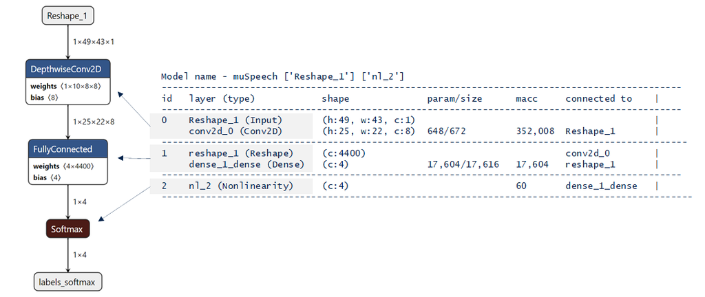

Figure 3: IR Graph (microSpeech)

[output not shown]

The right side of the table (`'c_*'` columns) reports generated C-object after optimization and rendering stages.

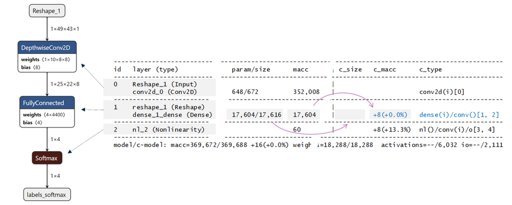

Figure 4: IR Graph with C-definitions

[output not shown]

Footer summarizes the differences for the whole model including the requested RAM size for the activations buffer and for the IO tensors.

```powershell
model/c-model: macc=369,672/369,688 +16(+0.0%) weights=18,288/18,288
           activations=--/6,032 io=--/2,111
```

In the case where the optimizer engine has folded or/and fused the IR nodes, the `'c_type'` is empty.

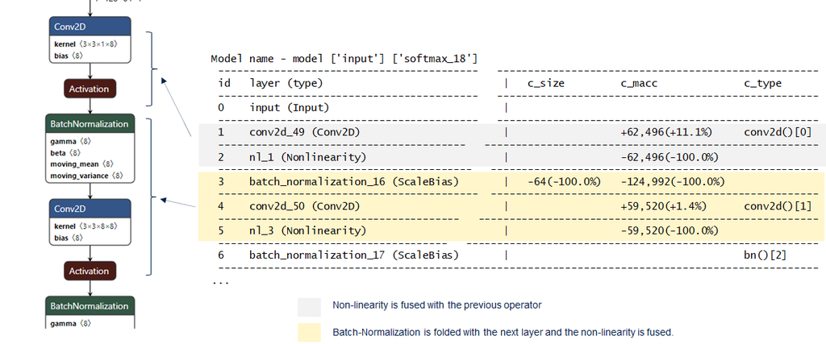

Figure 5: IR Graph - BN folding and NL fusing

Following figure is an example of IR graph with a residual neural network. As for the multiple branches, no specific information is added, `'connected to'` column allows to know the connections.

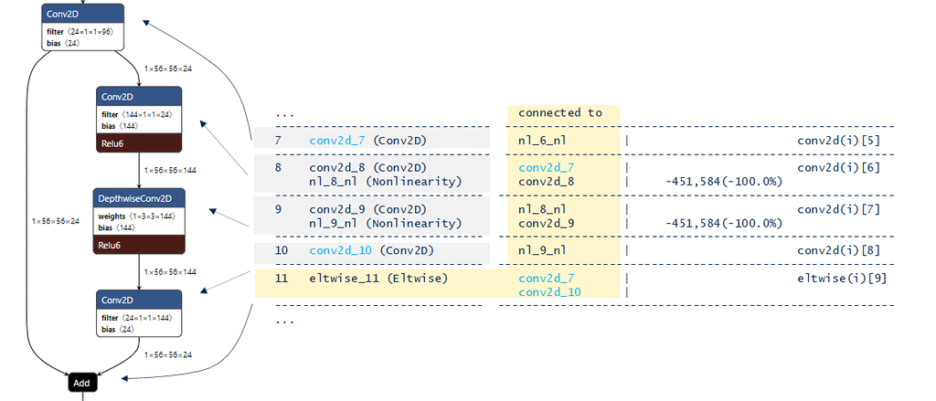

Figure 6: IR Graph - Residual case

**Warning** — For a compressed or quantized model, the MACC values (by layer or globally) are unchanged. Number of operations are always the same. Only the associated number of CPU cycles by MACC is changed. In particular, for the quantized models.

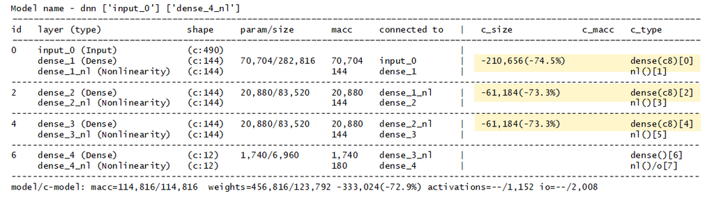

Figure 7: IR Graph - Compressed floating point model

## Complexity report per layer

The last part of the report summarizes the relative network complexity in term of MACC and associated ROM size by layer. Note that only the operators which contribute to the global `'c_macc'` and `'c_rom'` metrics are reported. `'c_id'` indicates the index of the associated c-node.

```powershell
 Complexity report per layer - macc=18,752,688 weights=7,552 act=3,097,600 ram_io=602,184
 ---------------------------------------------------------------------------------------------------
 id   name                             c_macc                    c_rom                     c_id
 ---------------------------------------------------------------------------------------------------
 1    separable_conv1                  ||                 1.8%   ||                 1.6%   [0]
 1    separable_conv1_conv2d           |||                3.2%   ||||               3.4%   [1]
 2    depthwise_conv2d_1               |||||||||         10.3%   ||||||||           8.5%   [2]
 3    conv2d_1                         ||||||||||||||||  17.6%   ||||||||||||||    14.4%   [3]
 5    dw_conv_branch1                  ||||||||           9.3%   ||||||||           8.5%   [7]
 6    pw_branch1                       ||||||||||||||||  17.6%   ||||||||||||||    14.4%   [8]
 7    dw_conv_branch0                  ||||||||           9.3%   ||||||||           8.5%   [6]
 8    batch_normalization_1            ||                 2.1%   ||                 1.7%   [9]
 9    separable_conv1_branch2          ||||||||           9.3%   ||||||||           8.5%   [4]
 9    separable_conv1_branch2_conv2d   |||||||||||||||   16.5%   ||||||||||||||    14.4%   [5]
 10   add_1                            ||                 2.1%   |                  0.0%   [10, 11]
 11   global_average_pooling2d_1       |                  1.0%   |                  0.0%   [12]
 12   dense_1                          |                  0.0%   ||||||||||||||||  16.2%   [13]
 12   dense_1_nl                       |                  0.0%   |                  0.0%   [14]
```

## C-graph description

Additional “Generated C-graph summary” section is included in the report (also displayed with `'-v 2'` argument). It summarizes the main computational and associated elements (c-objects) used by the C-inference engine (runtime library). It is based on the c-structures generated inside the `'<name>.c'` file. A complete graphic representation is available through the UI (refer to [[UM]](https://www.st.com/resource/en/user_manual/dm00570145.pdf)).

The first part re-calls the main structural elements: c-name, number of c-nodes, number of C-array for the data storage of the associated tensors. Input and output name of the I/O tensors.

```powershell
Generated C-graph summary
---------------------------------------------------------------------------------------------------
model name         : microspeech_01
c-name             : network
c-node #           : 5
c-array #          : 11
activations size   : 4352
weights size       : 16688
macc               : 336084
inputs             : ['Reshape_1_output_array']
outputs            : ['nl_2_fmt_output_array']
```

As illustrated in the figure 8, the implemented c-graph can be considered as a sequential graph, managed as a simple linked list. Fixed-executing order is defined by the C-code optimizer according two main criteria: data-path dependencies (or tensor dependencies) and the minimization of the RAM memory peak usage.

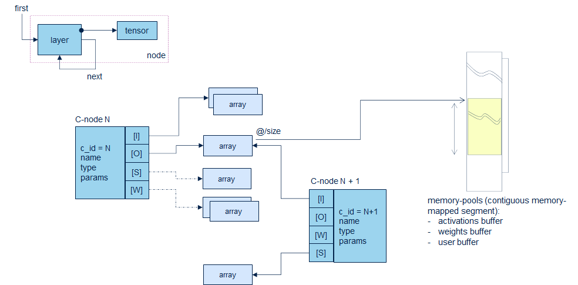

Figure 8: Computational c-graph objects

Each computational c-node is entirely defined by:

- operation type, parameters
- input tensors list: [I]
- *optional* weights/bias tensors list: [W]
- *optional* scratches tensors list: [S]
- outputs tensors list: [O]

### C-Arrays table

`'C-Arrays'` table lists the objects allowing to handle the base address, size and meta-data of the data memory segments for the different tensors. For each item, number of item, size in byte (`'item/size'`), memory segment location (`'mem-pool'`), type (`'c-type'`) and short format description (`'fmt'`) are reported.

```powershell
C-Arrays (11)
---------------------------------------------------------------------------------------------------
c_id  name (*_array)      item/size           mem-pool     c-type         fmt         comment
---------------------------------------------------------------------------------------------------
0     conv2d_0_scratch0   352/352             activations  uint8_t        int/ss
1     dense_1_bias        4/16                weights      const int32_t  int/ss
2     dense_1_weights     16000/16000         weights      const uint8_t  int/ua
3     conv2d_0_bias       8/32                weights      const int32_t  int/ss
4     conv2d_0_weights    640/640             weights      const uint8_t  int/ua
5     Reshape_1_output    1960/1960           user         uint8_t        int/us      /input
6     conv2d_0_output     4000/4000           activations  uint8_t        int/us
7     dense_1_output      4/4                 activations  uint8_t        int/ua
8     dense_1_fmt_output  4/16                activations  float          float
9     nl_2_output         4/16                activations  float          float
10    nl_2_fmt_output     4/4                 user         uint8_t        int/us      /output
---------------------------------------------------------------------------------------------------
```

| mem_pool | description |
| --- | --- |
| activations | part of the activations buffer |
| weights | part of a *ROM* segment |
| user | part of a memory segment owned by the user (client application layer) |

| fmt | format description |
| --- | --- |
| float | 32b float numbers |
| c4/c8 | compressed 32b float numbers. The size includes the dictionary. |
| int | quantized data memory chunk using integer format (refer to [QUANT]). `'/channel (n)'` indicates that per-channel scheme is used (else per-tensor). |

**C-Layers table**

`'C-Layers'` table lists the c-nodes. For each node, the c-name (`name`), type, macc, rom and associated tensors (with the shape for the I/O tensors) are reported. Associated c-array can be found with its name (or array id).

```powershell
C-Layers (5)
---------------------------------------------------------------------------------------------------
c_id  name (*_layer)  id  type    macc        rom         tensors                shape (array id)
---------------------------------------------------------------------------------------------------
0     conv2d_0        0   conv2d  320008      672         I: Reshape_1_output    [1, 49, 40, 1] (5)
                                                          S: conv2d_0_scratch0
                                                          W: conv2d_0_weights
                                                          W: conv2d_0_bias
                                                          O: conv2d_0_output     [1, 25, 20, 8] (6)
---------------------------------------------------------------------------------------------------
1     dense_1         1   dense   16000       16016       I: conv2d_0_output0    [1, 1, 1, 4000] (6)
                                                          W: dense_1_weights
                                                          W: dense_1_bias
                                                          O: dense_1_output      [1, 1, 1, 4] (7)
---------------------------------------------------------------------------------------------------
2     dense_1_fmt     1   nl      8           0           I: dense_1_output      [1, 1, 1, 4] (7)
                                                          O: dense_1_fmt_output  [1, 1, 1, 4] (8)
---------------------------------------------------------------------------------------------------
3     nl_2            2   nl      60          0           I: dense_1_fmt_output  [1, 1, 1, 4] (8)
                                                          O: nl_2_output         [1, 1, 1, 4] (9)
---------------------------------------------------------------------------------------------------
4     nl_2_fmt        2   nl      8           0           I: nl_2_output         [1, 1, 1, 4] (9)
                                                          O: nl_2_fmt_output     [1, 1, 1, 4] (10)
---------------------------------------------------------------------------------------------------
```

- `'id'` designates the layer/operator index from the original model allowing to retrieve the link with the implemented node (`'c_id'`).

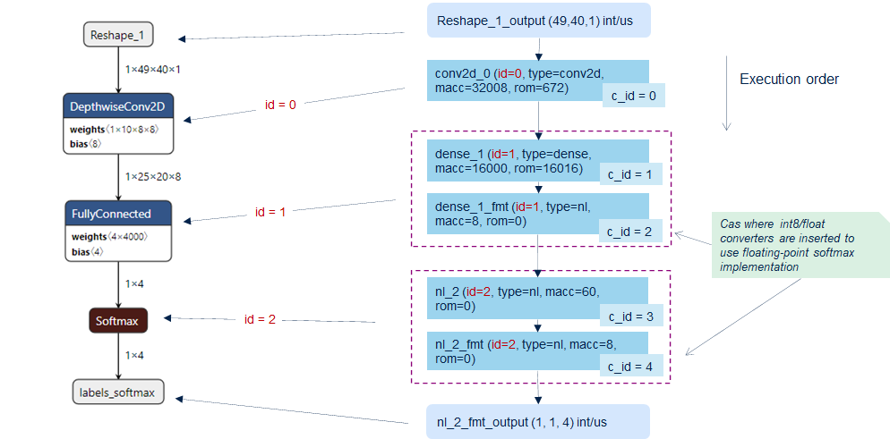

Figure 9: Original `'id'` and `'c_id'` mapping

# Validate command

## Description

The `'validate'` command allows to import, to render and to validate the generated C-files. Please refer to [[UM]](https://www.st.com/resource/en/user_manual/dm00570145.pdf), *“Validation engine”* and *“AI validation application”* sections to have an overview of the underlying process. In particular for the validation on target (`'--mode stm32'`), the STM32 board should be flashed with a validation firmware including the model. Detailed description of the used metrics are described in [METRIC].

## Specific arguments

[output not shown]

> The optional `--validate.batch_mode` option can be used when an input custom data set is used allowing to limit the number of samples. Two modes are possible,`'first'` to indicate that only the first `'batches'` samples are used and `'random'` to indicate that `'batches'` samples should be randomly selected with a fixed seed.

At the end of the process, results are summarized in a simple table (see [METRIC] for a detailed description of the results).

```powershell
Evaluation report (summary)
----------------------------------------------------------------------------------------------------------
Mode                 acc      rmse      mae       l2r       tensor
----------------------------------------------------------------------------------------------------------
x86 C-model #1       92.68%   0.053623  0.005785  0.340042  dense_4_nl [ai_float, [(1, 1, 36)], m_id=[10]]
original model #1    92.68%   0.053623  0.005785  0.340042  dense_4_nl [ai_float, [(1, 1, 36)], m_id=[10]]
X-cross #1           100.00%  0.000000  0.000000  0.000000  dense_4_nl [ai_float, [(1, 1, 36)], m_id=[10]]
----------------------------------------------------------------------------------------------------------
```

## Examples

- Minimal command to validate a 32b float model with the self-generated random input data (“Validation on desktop”).

  ```powershell
  $ stm32ai validate -m <model_f32p_file_path>
  ```

- To report the “L2r error” and relative execution time by layer (“Validation on desktop”).

  ```powershell
  $ stm32ai validate -m <model_f32p_file_path> --full
  ```

- Minimal command to validate a 32b float model on STM32 target. Note that a complete profiling report including execution time by layer is generated by default.

  ```powershell
  $ stm32ai validate -m <model_f32p_file_path> --mode stm32
  ```

- Validation of a 32b float model with self-generated random input data and compression factor (“Validation on desktop”)

  ```powershell
  $ stm32ai validate -m <model_f32p_file_path> -c 4
  ```

- Validate a model with a custom data set

```powershell
$ stm32ai validate -m <model_file_path> -vi test_data.csv
```

- Validate a quantized model with a custom data set

  ```powershell
  $ stm32ai validate -m <modified_model_file>.h5 -q <quant_file_desc>.json -vi test_data.npz
  ```

- Validate a model with only 20 randomly selected samples from a large custom data set

  ```powershell
  $ stm32ai validate -m <modified_model_file>.h5 -vi test_large_data.npz --validate.batch_mode random -b 20
  ```

## Serial COM port configuration

The `'--desc/-d'` argument should be used to indicate how to configure the serial COM driver to access the STM32 board. Previously, the STM32 board should be flashed with an *aiValidation* application (refer to [[UM]](https://www.st.com/resource/en/user_manual/dm00570145.pdf), *“AI validation application”* section).

By default, an auto-detection mechanism is applied to discover a connected board at @115200 (default value: `default:115200`)

  ```powershell
  $ stm32ai validate -m <model_file_path> --mode stm32 -d 921600
  ```

- set the COM port to `COM16` (Windows case ) or `/dev/ttyACM0` (Linux case)

  ```powershell
  $ stm32ai validate -m <model_file_path> --mode stm32 -d COM16
  $ stm32ai validate -m <model_file_path> --mode stm32 -d /dev/ttyACM0
  ```

- set the COM port to `COM16` and the baud-rate @921600

  ```powershell
  $ stm32ai validate -m <model_file_path> --mode stm32 -d COM16:921600
  ```

## Extended complexity report per layer

If `'-v 2'` option is used, the “Complexity report per layer” table is extended with a specific column to report the metric according the data type: `'l2r'` for the floating point models and `'rmse'` for the integer or quantized models. By default, the metric is computed only on the last layers (outputs of the model), however for the Keras floating point model, the `'--full'` option allows to compute this error layer-by-layer.

* indicates the max value

```powershell
$ stm32ai validate -m <model_f32p_file_path> -v 2
...
 Complexity report per layer - macc=4,013 weights=15,560 act=192 ram_io=416
 ---------------------------------------------------------------------------------------------------------
 id   name           c_macc                    c_rom                     c_id   c_dur    l2r (X-CROSS)
 ---------------------------------------------------------------------------------------------------------
 0    dense_1        ||||||||||||||||  82.2%   ||||||||||||||||  84.8%   [0]     11.3%
 1    activation_1   |                  0.8%   |                  0.0%   [1]     13.3%
 2    dense_2        |||               12.7%   |||               13.1%   [2]     16.5%
 3    activation_2   |                  0.4%   |                  0.0%   [3]     17.7%
 4    dense_3        |                  2.0%   |                  2.1%   [4]     19.4%
 5    activation_3   |                  1.9%   |                  0.0%   [5]     21.9%   3.95458301e-07 *
...
```

```powershell
$ stm32ai validate -m <model_f32p_file_path> --full
...
 Complexity report per layer - macc=4,013 weights=15,560 act=192 ram_io=416
 ---------------------------------------------------------------------------------------------------------
 id   name           c_macc                    c_rom                     c_id   c_dur    l2r (X-CROSS)
 ---------------------------------------------------------------------------------------------------------
 0    dense_1        ||||||||||||||||  82.2%   ||||||||||||||||  84.8%   [0]     11.0%   5.62010030e-08
 1    activation_1   |                  0.8%   |                  0.0%   [1]     13.3%   5.57235715e-08
 2    dense_2        |||               12.7%   |||               13.1%   [2]     16.3%   8.20674515e-08
 3    activation_2   |                  0.4%   |                  0.0%   [3]     18.0%   8.00048383e-08
 4    dense_3        |                  2.0%   |                  2.1%   [4]     19.6%   1.32168850e-07
 5    activation_3   |                  1.9%   |                  0.0%   [5]     21.9%   3.95458301e-07 *
...
```

**Warning** — `'--full'` option can be also used for validation on target (`'--mode stm32'`), to report the *L2r* error per layer, however, be aware that the validation time is significantly increased due to the upload of the intermediate results.

## Execution time per layer

### Validation on target

The validation on target allows to have a *full and accurate profiling* report including:

- inference-time
- number of CPU cycles by MACC
- execution time per layer
- STM32 HW settings/configurations (clock frequency, memory configuration)

**Note** — All these information are also available through the *“aiSystemPerformance”* application (refer to [[UM]](https://www.st.com/resource/en/user_manual/dm00570145.pdf))

```powershell
...
Running the STM AI c-model (AI RUNNER)...(name=network, mode=stm32)

 STM Proto-buffer protocol 2.2 (SERIAL:COM6:115200:connected) ['network']

 Summary "network" - ['network']
 --------------------------------------------------------------------------------
 inputs/outputs       : 1/1
 input_1              : (1, 1, 1, 1960), int8, 1960 bytes, scale=0.10171568393707275, zp=-128, user
 output_1             : (1, 1, 1, 4), int8, 4 bytes, scale=0.00390625, zp=-128, user
 n_nodes              : 5
 compile_datetime     : Jun 11 2021 23:37:49 (Mon May 31 11:47:28 2021)
 activations          : 5712
 weights              : 16688
 macc                 : 336088
 --------------------------------------------------------------------------------
 runtime              : Protocol 2.2 - STM.AI (/gcc) 7.0.0 (Tools 7.0.0)
 capabilities         : ['IO_ONLY', 'PER_LAYER', 'PER_LAYER_WITH_DATA', 'SELF_TEST']
 device               : 0x431 - STM32F411xC/E @100/100MHz fpu,art_lat=3,art_prefetch,
                        art_icache,art_dcache
 --------------------------------------------------------------------------------

 Results for 10 inference(s) - average per inference
  device              : 0x431 - STM32F411xC/E @100/100MHz fpu,art_lat=3,art_prefetch,
                        art_icache,art_dcache
  duration            : 34.089ms
  CPU cycles          : 3408875
  cycles/MACC         : 10.14
  c_nodes             : 5

 c_id  m_id  desc            oshape          fmt      ms          %
 ---------------------------------------------------------------------------
 0     1     Conv2D (0x103)  (1, 25, 20, 8)  int8         33.478   98.2%
 1     2     Dense (0x104)   (1, 1, 1, 4)    int8          0.592    1.7%
 2     2     NL (0x107)      (1, 1, 1, 4)    float32       0.003    0.0%
 3     3     NL (0x107)      (1, 1, 1, 4)    float32       0.011    0.0%
 4     3     NL (0x107)      (1, 1, 1, 4)    int8          0.004    0.0%
 ---------------------------------------------------------------------------
                                                          34.089 ms
...
```

This report can be used to identify the main contributors and to re-fine the model accordingly. `'c_id'` column references the index of the c-node (see “C-graph description” section) and the `'m_id'` indicates the index from the original model.

### stm32 out-of-the-box execution

When `'stm32_io_only'` mode is used, the stm32 model is only executed out-of-the-box. Executing time or l2r per layer are no more computed. This can be used to limit the traffic between the host and the target decreasing the validation time.

### Validation on desktop

For the validation on desktop, by default a relative execution time per layer is also reported. Nevertheless, it is important to note that the values are only the **indicators**, they are dependent on the implementation of the kernels which are not optimized and the work-load of the desktop machine in contrary to the reported inference times for the validation on target.

```powershell
...
Running the STM AI c-model (AI RUNNER)...(name=network, mode=x86)

 X86 shared lib (<model_build_path>\libai_network.dll) ['network']

 Summary "network" - ['network']
 --------------------------------------------------------------------------------
 inputs/outputs       : 1/1
 input_1              : (1, 1, 1, 1960), int8, 1960 bytes, scale=0.10171568393707275, zp=-128, user
 output_1             : (1, 1, 1, 4), int8, 4 bytes, scale=0.00390625, zp=-128, user
 n_nodes              : 5
 compile_datetime     : Jun 11 2021 23:48:50 (Fri Jun 11 23:48:48 2021)
 activations          : 5712
 weights              : 16688
 macc                 : 336088
 --------------------------------------------------------------------------------
 runtime              : STM.AI 7.0.0 (Tools 7.0.0)
 capabilities         : ['IO_ONLY', 'PER_LAYER', 'PER_LAYER_WITH_DATA']
 device               : AMD64 Intel64 Family 6 Model 78 Stepping 3, GenuineIntel (Windows)
 --------------------------------------------------------------------------------

 Results for 10 inference(s) - average per inference
  device              : AMD64 Intel64 Family 6 Model 78 Stepping 3, GenuineIntel (Windows)
  duration            : 5.875ms
  c_nodes             : 5

 c_id  m_id  desc            oshape          fmt      ms          %
 ---------------------------------------------------------------------------
 0     1     Conv2D (0x103)  (1, 25, 20, 8)  int8          1.136   19.3%
 1     2     Dense (0x104)   (1, 1, 1, 4)    int8          1.182   20.1%
 2     2     NL (0x107)      (1, 1, 1, 4)    float32       1.184   20.2%
 3     3     NL (0x107)      (1, 1, 1, 4)    float32       1.187   20.2%
 4     3     NL (0x107)      (1, 1, 1, 4)    int8          1.188   20.2%
 ---------------------------------------------------------------------------
                                                           5.875 ms

 NOTE: duration and exec time per layer is just an indication. They are dependent
       of the HOST-machine work-load.
...
```

- `'c_id'` designates the c-layer index in the “C-graph description”.

**Warning** — Reported execution time per layer and global inference time are just the indicators. Be aware that the X86 C network runtime has been designed as an emulation of the STM32 C network runtime allowing efficient functional verification flow w/o STM32 board.

# Generate command

## Description

The `'generate'` command is used to generate the specialized network and data C-files.

```powershell
$ stm32ai generate -m <model_file_path> -o <output-directory-path>
...
Generated files (5)
-----------------------------------------------------------
 <output-directory-path>\<name>_config.h
 <output-directory-path>\<name>.c
 <output-directory-path>\<name>_data.c
 <output-directory-path>\<name>.h
 <output-directory-path>\<name>_data.h

Creating report file <output-directory-path>\network_generate_report.txt
...
```

- `'<name>.c/.h'` files contain the topology of the C-model (C-struct definition of the tensors and the operators), including the embedded inference client API (refer to [API]) to use the generated c-model on the top of the optimized inference runtime library.
- `'<name>_data.c/.h'` files are by default a simple C-array with the data of the weight/bias tensors. However, the `'--split-weights'` option allows to have a C-array by tensor (refer to [API], “*Split weights buffer*” section) and the `'--binary'` option creates a binary file with the data of the weight/bias tensors. The `'--relocatable'` option allows to generate a relocatable binary model including the topology definition, the requested kernels and the weights in a single binary file (refer to [RELOC]).

## Specific arguments

[output not shown]

Specific arguments to generate a relocatable binary model (refer to [RELOC] for details).

[output not shown]

**Warning** — the `--split-weights` and `--copy-weights-at` features are not supported with the `--relocatable` option.

## Examples

- Generate the specialized NN C-files (default options).

  ```powershell
  $ stm32ai generate -m <model_file_path>
  ```

- Generate the specialized NN C-files for a 32b float model with compression factor.

  ```powershell
  $ stm32ai generate -m <model_file_path> -c 8
  ```

- Generate the specialized NN C-files for a Keras post-quantized model.

  ```powershell
  $ stm32ai generate -m <model_file_path> -q <quant_file_desc>.json
  ```

- Generate only the network NN C-file, weights/bias parameters are provided as a binary file/object.

  ```powershell
  $ stm32ai generate -m <model_file_path> -o <output-directory-path> -n <name> --binary
  ...
  Generated files (6)
  -----------------------------------------------------------
   <output-directory-path>\<name>_config.h
   <output-directory-path>\<name>.h
   <output-directory-path>\<name>.c
   <output-directory-path>\<name>_data.bin
   <output-directory-path>\<name>_data.h
   <output-directory-path>\<name>_data.c

  Creating report file <output-directory-path>\<name>_generate_report.txt
  ...
  ```

- Generate a full relocatable binary file for a STM32H7 series (refer to [RELOC]).

  ```powershell
  $ stm32ai generate -m <model_file_path> -o <output-directory-path> --relocatable --series stm32h7
  ...
  Generated files (8)
  -----------------------------------------------------------
   <output-directory-path>\<name>_config.h
   <output-directory-path>\<name>.h
   <output-directory-path>\<name>.c
   <output-directory-path>\<name>_data.h
   <output-directory-path>\<name>_data.c
   <output-directory-path>\<name>_rel.bin
   <output-directory-path>\<name>_img_rel.c
   <output-directory-path>\<name>_img_rel.h

  Creating report file <output-directory-path>\network_generate_report.txt
  ...
  ```

  ```powershell
  $ stm32ai generate -m <model_file_path> -o <output-directory-path> -n <name> --relocatable --binary
  ...
  Generated files (9)
  -----------------------------------------------------------
   <output-directory-path>\<name>_config.h
   <output-directory-path>\<name>.h
   <output-directory-path>\<name>.c
   <output-directory-path>\<name>_data.h
   <output-directory-path>\<name>_data.c
   <output-directory-path>\<name>_data.bin
   <output-directory-path>\<name>_rel.bin
   <output-directory-path>\<name>_img_rel.c
   <output-directory-path>\<name>_img_rel.h

  Creating report file <output-directory-path>\<name>_generate_report.txt
  ...
  ```

## Particular network data c-file

The helper `'--address'` and `'--copy-weights-at'` options are the convenience options to generate a specific `ai_network_data_weights_get()` function. The returned address is passed to the `ai_<network>_init()` function thanks the `ai_network_params` structure (refer to [API]). Note that this (including copy function) can be fully managed by the application code itself.

If the `--binary` (or `--relocatable`) option is passed without the `'--address'` or `'--copy-weights-at'` arguments, following `network_data.c` file is generated

```c
#include "network_data.h"

ai_handle ai_network_data_weights_get(void)
{
  return AI_HANDLE_NULL;
}
```

Example of generated `network_data.c` file with the `--binary` and `--address 0x810000` options.

```c
#include "network_data.h"

#define AI_NETWORK_DATA_ADDR 0x810000

ai_handle ai_network_data_weights_get(void)
{
  return AI_HANDLE_PTR(AI_NETWORK_DATA_ADDR);
}
```

Example of generated `network_data.c` file with the `--binary`, `--address 0x810000` and `--copy-weights-at 0xD0000000` options.

```c
#include <string.h>
#include "network_data.h"

#define AI_NETWORK_DATA_ADDR 0x81000
#define AI_NETWORK_DATA_DST_ADDR 0cD0000000

ai_handle ai_network_data_weights_get(void)
{
  memcpy((void *)AI_NETWORK_DATA_DST_ADDR, (const void *)AI_NETWORK_DATA_ADDR,
                                            AI_NETWORK_DATA_WEIGHTS_SIZE);
  return AI_HANDLE_PTR(AI_NETWORK_DATA_DST_ADDR);
}
```

## Update an ioc-based project

For a X-CUBE-AI IDE project (ioc-based), the user has the possibility to update only the generated NN C-files. In this case, the `'--output'` option is used to indicate the root directory of the IDE project, i.e. location of the `'.ioc'` file. The destination of the previous NN c-files are automatically discovered in the source tree else output directory is used.

```powershell
$ stm32ai generate -m <model_path> -n <name> -c 4 -o <root_project_folder>
...
IOC file found in the output directory
...
Generated files (5)
-----------------------------------------------------------
 <root_project_folder>\Inc\<name>_config.h
 <root_project_folder>\Src\<name>.c
 <root_project_folder>\Src\<name>_data.c
 <root_project_folder>\Inc\<name>.h
 <root_project_folder>\Inc\<name>_data.h

Creating report file <root_project_folder>\<name>_generate_report.txt
...
```

For multiple networks support, the update mechanism for a particular model is the same. **Users** should be vigilant to use the correct *name* (`'--name my_name'`) to avoid to overwrite/update an incorrect file and to be aligned with the multi-network helpers functions which are only generated by the X-CUBE-AI UI: `'app_x-cube-ai.c/.h'` files. If the number of networks is changed, X-CUBE-AI UI should be used to update the generated c-models.

## Update a proprietary source tree

The `'--output'` option is used to indicate the single destination of the generated NN C-files. Note that an empty file with the `'.ioc'` extension can be defined in the root directory of the custom source tree to use the discovery mechanism as for the update of an ioc-based project.

# Supported-ops command

## Description

The `'suppoorted-ops'` command is used to display the list of the supported operators for a given deep learning framework with the `'-t/--type'` option. Else by default, all operators are listed.

## Specific arguments

| parameter | description |
| --- | --- |
| `--with-report` | if defined, this flag allows to generate a report, txt file (Markdown format) with the list of the operators and associated constraints. - *Optional* |

This option has been used to generate the following articles: “Keras toolbox support”, "TFLite toolbox support and “ONNX toolbox support”

## Examples

- Generate the list of the supported operators (default)

  ```powershell
  $ stm32ai supported-ops
  Neural Network Tools for STM32AI v1.5.1 (STM.ai v7.0.0)
  246 operators found
      Abs (ONNX), ABS (TFLITE), Acos (ONNX), Acosh (ONNX), Activation (KERAS),
      ActivityRegularization (KERAS), Add (KERAS), Add (ONNX), ADD (TFLITE),
      AlphaDropout (KERAS), And (ONNX), ARG_MAX (TFLITE), ARG_MIN (TFLITE),
      ArgMax (ONNX), ArgMin (ONNX), ArrayFeatureExtractor (ONNX), Asin (ONNX),
      Asinh (ONNX),...
  ```

- Generate the list of the supported Keras operators

  ```powershell
  $ stm32ai supported-ops -t keras
  Neural Network Tools for STM32AI v1.5.1 (STM.ai v7.0.0)
  Parsing operators for KERAS toolbox
  53 operators found
      Activation, ActivityRegularization, Add, AlphaDropout, Average, AveragePooling1D,
      AveragePooling2D, BatchNormalization, Bidirectional, Concatenate, Conv1D, Conv2D,
      Conv2DTranspose, Cropping1D, Cropping2D, CustomUnpack, Dense, DepthwiseConv2D,
      Dropout, ELU, Flatten, GaussianDropout, GaussianNoise, GlobalAveragePooling1D,
      GlobalAveragePooling2D, GlobalMaxPooling1D, GlobalMaxPooling2D, GRU, InputLayer,
      LeakyReLU, LSTM, Maximum, MaxPooling1D, MaxPooling2D, Minimum, Multiply, Permute,
      PReLU, ReLU, RepeatVector, Reshape, SeparableConv1D, SeparableConv2D, Softmax,
      SpatialDropout1D, SpatialDropout2D, Subtract, ThresholdedReLU, TimeDistributed,
      UpSampling1D, UpSampling2D, ZeroPadding1D, ZeroPadding2D
  26 custom operators found
      Abs, Acos, Acosh, Asin, Asinh, Atan, Atanh, Ceil, Clip, Cos, Exp, Fill,
      FloorDiv, FloorMod, Gather, Lambda, Log, Pow, Reshape, Round, Shape, Sign,
      Sin, Sqrt, Square, Tanh
  ```

- Generate the list of the supported ONNX operators

  ```powershell
  $ stm32ai supported-ops -t onnx
  ```

- Generate the list of the supported tflite operators

  ```powershell
  $ stm32ai supported-ops -t tflite
  ```

- Generate the list of the supported Keras operators with a full report

  ```powershell
  $ stm32ai supported-ops -t keras --with-report
  ...
  Building report..
  creating file : <output-directory-path>/supported_ops_keras.md
  ```

# References

| ref | description |
| --- | --- |
| [DS] | X-CUBE-AI - AI expansion pack for STM32CubeMX https://www.st.com/en/embedded-software/x-cube-ai.html |
| [UM] | User manual - Getting started with X-CUBE-AI Expansion Package for Artificial Intelligence (AI) [(pdf)](https://www.st.com/resource/en/user_manual/dm00570145.pdf) |
| [CLI] | stm32ai - Command Line Interface (link) |
| [API] | Embedded inference client API (link) |
| [METRIC] | Evaluation report and metrics (link) |
| [TFL] | TensorFlow Lite toolbox (link) |
| [KERAS] | Keras toolbox (link) |
| [ONNX] | ONNX toolbox (link) |
| [FAQS] | FAQ generic, validation, quantization |
| [QUANT] | Quantization and quantize command (link) |
| [RELOC] | Relocatable binary network support (link) |
| [CUST] | Support of the Keras Lambda/custom layers (link) |
| [TFLM] | TensorFlow Lite for Microcontroller support (link) |
| [INST] | Setting the environment (link) |
| [OBS] | Platform Observer API (link) |
| [C-RUN] | Executing locally a generated c-model (link) |